# R Notebook

```r
library(MALDIquant)
library(MALDIquantForeign)
library(MALDIrppa)
library(tidyverse)
library(parallel)
library(ggpubr)
library(ggrepel)
library(MassSpecWavelet)
```

```r
# Set data and results folders
basepath = '~/palaeoproteomics/MALDI/spanish_book'
data_folder = file.path(basepath, 'data')
results_folder = file.path(basepath, 'results')
# Set parameters
int_threshold = 50
hws = 20
tolerance = 0.002
iterations = 100
thScale = 2.5
n_procs = 6L
minFreq = 0.6
```

```r
# Read metadata and data
uoc_metadata = read.csv(file.path(data_folder,'uoc_metadata.csv'), stringsAsFactors=F)
uoc_metadata$sample.name = as.character(uoc_metadata$sample.name)
uoc_data = importMzMl(file.path(data_folder, 'UoC_mzml'), mc.cores=1)

spectra = c()
sample_fac = c()
label_fac = c()
batch_fac = c()
for(i in 1:dim(uoc_metadata)[1]){
  n = uoc_metadata$replicates[i]
  s = uoc_metadata$sample.name[i]
  sp = uoc_metadata$species[i]
  b = uoc_metadata$batch[i]
  spectra = c(spectra, paste0(s, '_', seq(1, n)))
  sample_fac = c(sample_fac, rep(s, n))
  label_fac = c(label_fac, rep(sp, n))
  batch_fac = c(batch_fac, rep(b, n))
}
spectra_metadata = data.frame(
  'spectra'=as.character(spectra),
  'sample'=as.factor(sample_fac),
  'label'=as.factor(label_fac),
  'batch'=as.factor(batch_fac)
)
spectra_metadata$idx = seq(1,nrow(spectra_metadata))

# Include sample metadata
uoc_data = mapply(
  function(x, val, slot){
    metaData(x)[[slot]] = as.character(val)
    return(x)
  },
  uoc_data, spectra_metadata$sample,
  MoreArgs = list(slot='sampleName')
)
names(uoc_data) = spectra_metadata$spectra
```

## Spectra QC screening

We use MALDIrppa screening function and plot the spectra that are labeled as failure

```r
# Initial screening
sc.results = screenSpectra(uoc_data)
```

```
## The default of 'doScale' is FALSE now for stability;
##   set options(mc_doScale_quiet=TRUE) to suppress this (once per session) message
```

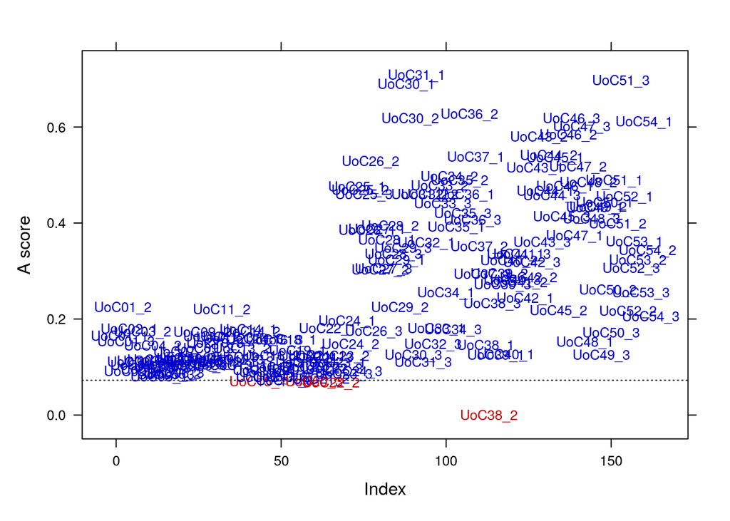

```r
rownames(sc.results$est.table) = spectra_metadata$spectra
plot(sc.results, labels=T)
```

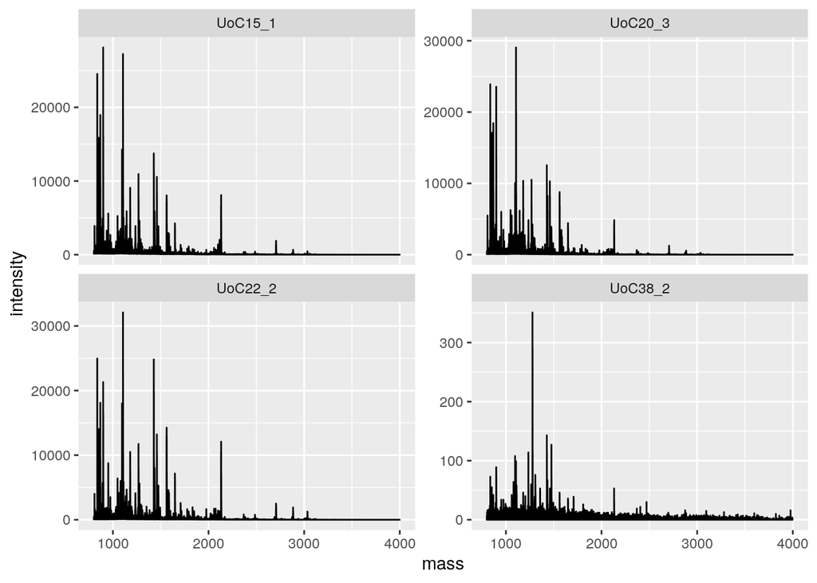

```r
qc_control = as_tibble(sc.results$est.table)
failure = qc_control %>% filter(Class == "failure") %>% pull(ID)

f_spec = lapply(failure,
       function(i){
         x = as_tibble(as.matrix(uoc_data[[i]]))
         x$spectra = i
         x
       })
names(f_spec) = failure
f_spec = as_tibble(bind_rows(f_spec))

p = ggplot(f_spec) +
  geom_line(aes(x=mass, y=intensity)) +
  facet_wrap(vars(spectra), scales = "free_y")
p
```

```r
ggsave('qc_spectra.png', p, path=results_folder, width = 9, height = 6)
```

## Initial preprocessing of the spectra

The initial preprocessing consists of:

1. Squared root intensity transformation.
2. Undecimated wavelet transform smoothing. `wavSmoothing` function on `MALDIrppa` package
3. Baseline correction
4. Probabilistic Quotient Normalization.

```r
preprocessing = function(x, iters, thScale){

  # Intensity transformation
  x = transformIntensity(x, 'sqrt')

  # Smoothing
  # x = smoothIntensity(x, method = 'SavitzkyGolay',
  #                     halfWindowSize = hws)

  x = unlist(wavSmoothing(list(x), thresh.scale = thScale))

  # Base line correction
  x = removeBaseline(x, method='SNIP', iterations=iters)

  # Normalization
  x = calibrateIntensity(x, method="PQN") # or TIC

  return(x)

}
```

```r
# Preprocess
preprocessed_l = mclapply(uoc_data, preprocessing, iterations, thScale,
                           mc.cores=n_procs)
preprocessed_l = unlist(preprocessed_l)
```

## Noise estimation and testing

We test 3 different algorithms to estimate noise and detect peaks

1. Median absolute deviation (MAD).
2. SuperSmoother.
3. Continuous Wavelet Transofrm (CWT). This method works on the raw spectra without any preprocessing.

We test signal-to-noise ratios (SNR) thresholds: 2, 3, 4, 5, 6, 8. on a random sample

```r
snr_values = c(2, 3, 4, 5, 6, 8)

spectra_index = 142
spectra_test = preprocessed_l[[spectra_index]]
unproc_spectra_test = uoc_data[[spectra_index]]
snr_colors= c('turquoise2', 'violetred4', 'red', 'orange', 'green', 'blue')
```

```r
custom_peakDetectionCWT = function(s, SNR.Th = 2, nearbyPeak = T){
  majorPeakInfo = peakDetectionCWT(s@intensity, SNR.Th = SNR.Th, nearbyPeak = nearbyPeak)$majorPeakInfo
  tunnedPeakInfo = tuneInPeakInfo(s@intensity, majorPeakInfo)
  # Filter masses and intensities with the peakIndex
  p = createMassPeaks(mass=s@mass[tunnedPeakInfo$peakIndex],
                      intensity=s@intensity[tunnedPeakInfo$peakIndex],
                      snr=majorPeakInfo$peakSNR[names(tunnedPeakInfo$peakIndex)])
  return(p)
}


listPeakDetectionCWT = function(sl, ...){
  mclapply(
    sl,
    custom_peakDetectionCWT,
    ...
  )
}


get_peaks = function(sl, detectionMethod='SuperSmoother', ...){
  # args in ... SNR, halfWindowSize, mc.cores
  args = list(...)
  if (is.null(args$mc.cores)){
    args$mc.cores=1
  }
  if (detectionMethod %in% c('MAD', 'SuperSmoother')){
    pl = do.call(detectPeaks, c(list(object=sl, method=detectionMethod), args))
  } else if (detectionMethod=='CWT'){
    pl = listPeakDetectionCWT(sl, SNR.Th=args$SNR, mc.cores=args$mc.cores)
  }
  return(pl)
}

plot_noise = function(s, methods, SNRvalues, colors, nps=NULL){
  par(mfrow=c(length(methods),1))
  for (m in methods){
    if (m != 'CWT'){
      noise = estimateNoise(spectra_test, method=m)
      plot(
        s, main = paste0(m, " noise estimator."), sub=NULL,
        xlim=c(min(s@mass), max(s@mass)), ylim=c(0, max(s@intensity))
      )
      legend(x='topright', legend=c('Noise', paste0('SNR=', SNRvalues)),
             col=c('red', colors), lty=c(5, rep(1,length(SNRvalues))), lwd=rep(2,length(SNRvalues)+1))
      lines(noise, col="red", lwd=2, lty=5)
    } else if (m == 'CWT' & !is.null(nps)) {
      plot(
        nps, main = paste0(m, " noise estimator."), sub=NULL,
        xlim=c(min(nps@mass), max(nps@mass)), ylim=c(0, max(nps@intensity))
      )
      legend(x='topright', legend=c(paste0('SNR=', SNRvalues)),
             col=c(colors), lty=rep(1,length(SNRvalues)), lwd=rep(2,length(SNRvalues)))
    }
    for (i in 1:length(SNRvalues)){
      if (m != 'CWT'){
        lines(noise[,1], noise[, 2]*SNRvalues[i], col=colors[i], lwd=2)
      } else if (m == 'CWT' & !is.null(nps)) {
        p = custom_peakDetectionCWT(nps, SNR.Th = SNRvalues[i], nearbyPeak = T)
        noise = p@intensity/p@snr
        snr_th = noise * SNRvalues[i]
        lines(p@mass, snr_th, col=colors[i], lwd=2)
      }
    }
  }
}
```

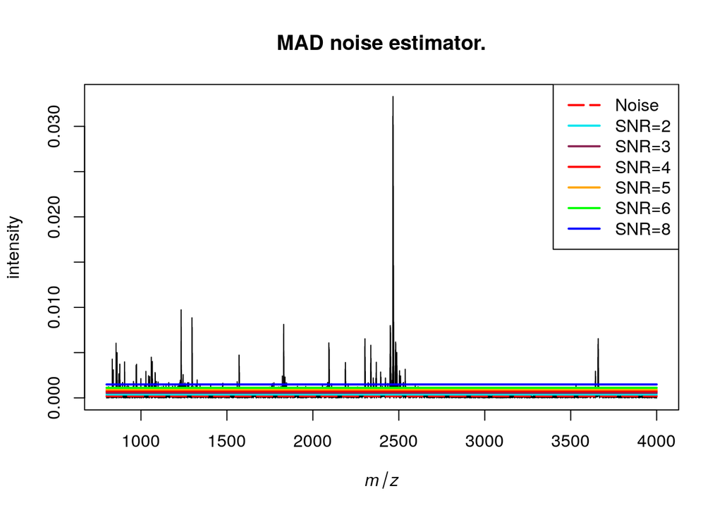

```r
plot_noise(
  spectra_test, methods=c('MAD'),
  SNRvalues=snr_values,
  colors=snr_colors
)
```

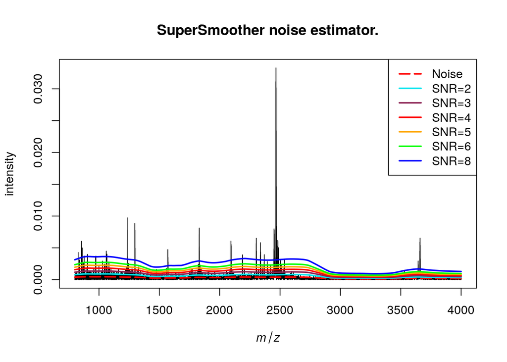

```r
plot_noise(
  spectra_test, methods=c('SuperSmoother'),
  SNRvalues=snr_values,
  colors=snr_colors
)
```

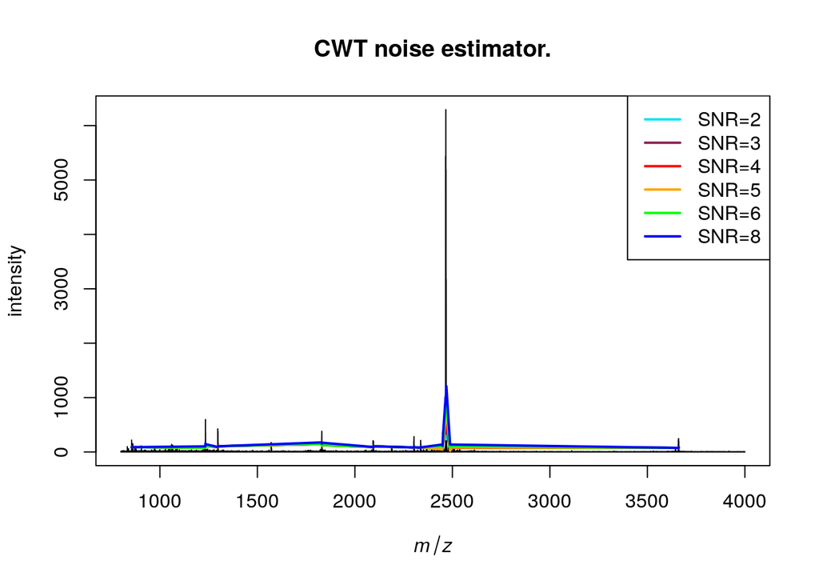

```r
plot_noise(
  spectra_test, methods=c('CWT'),
  SNRvalues=snr_values,
  colors=snr_colors,
  nps=unproc_spectra_test
)
```

```r
plot_peaks = function(s, p, method, snr, col){
  plot(s,
       xlim=c(min(s@mass), max(s@mass)),
       ylim=c(0, max(s@intensity)),
       main=NULL,
       sub=NULL)
  points(p, col=col, pch=4)
  legend(x='topright', legend=paste0('SNR=',snr), col=col, lty=1, pch=4)
}
```

### MAD noise estimator

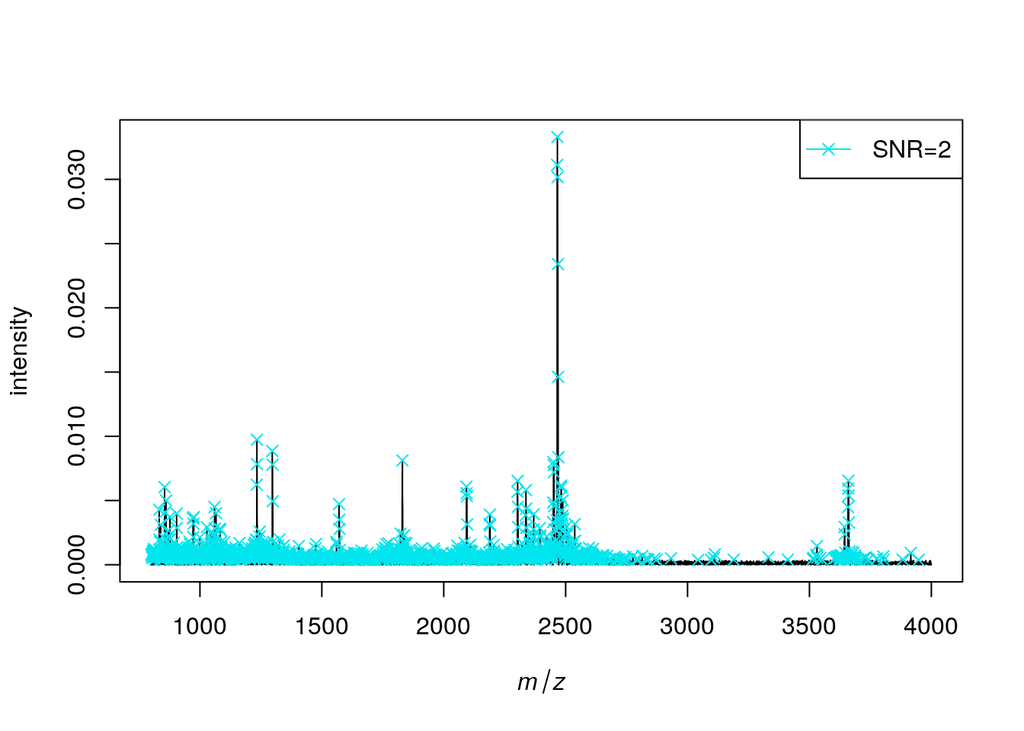

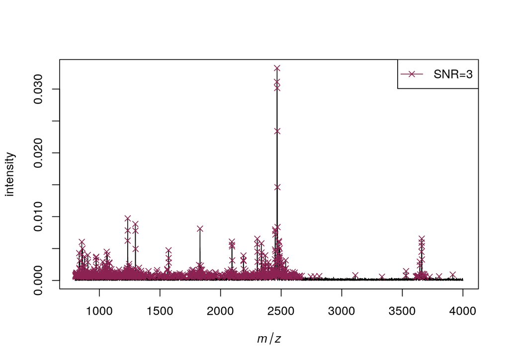

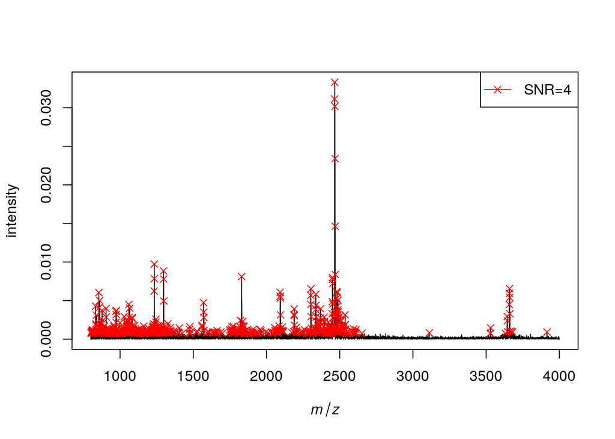

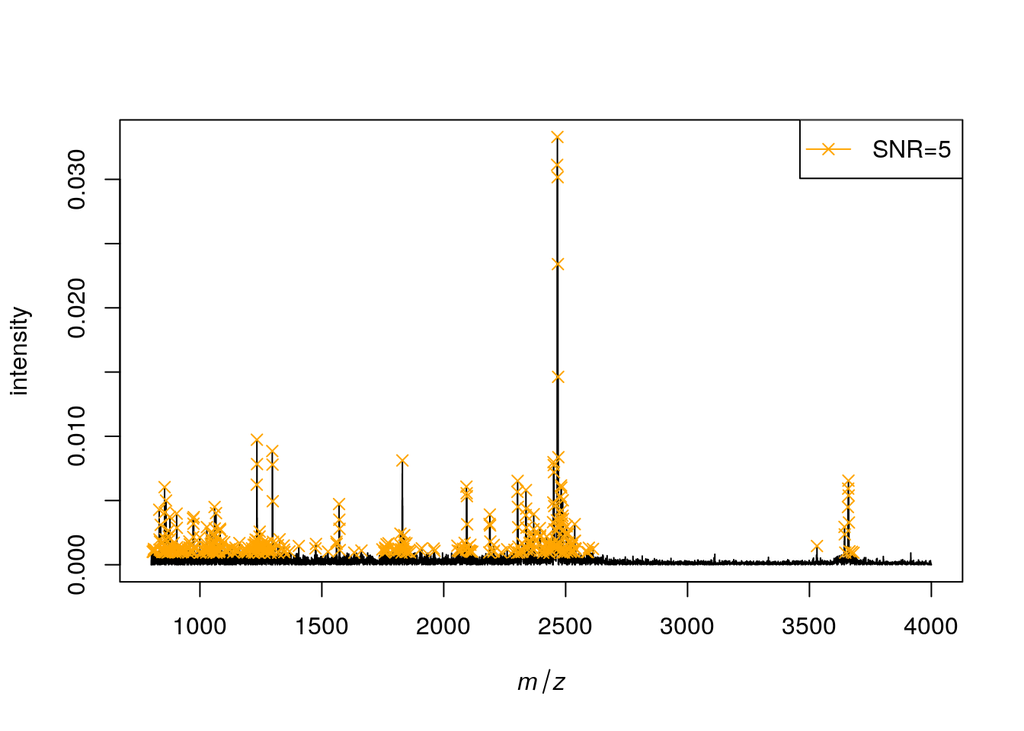

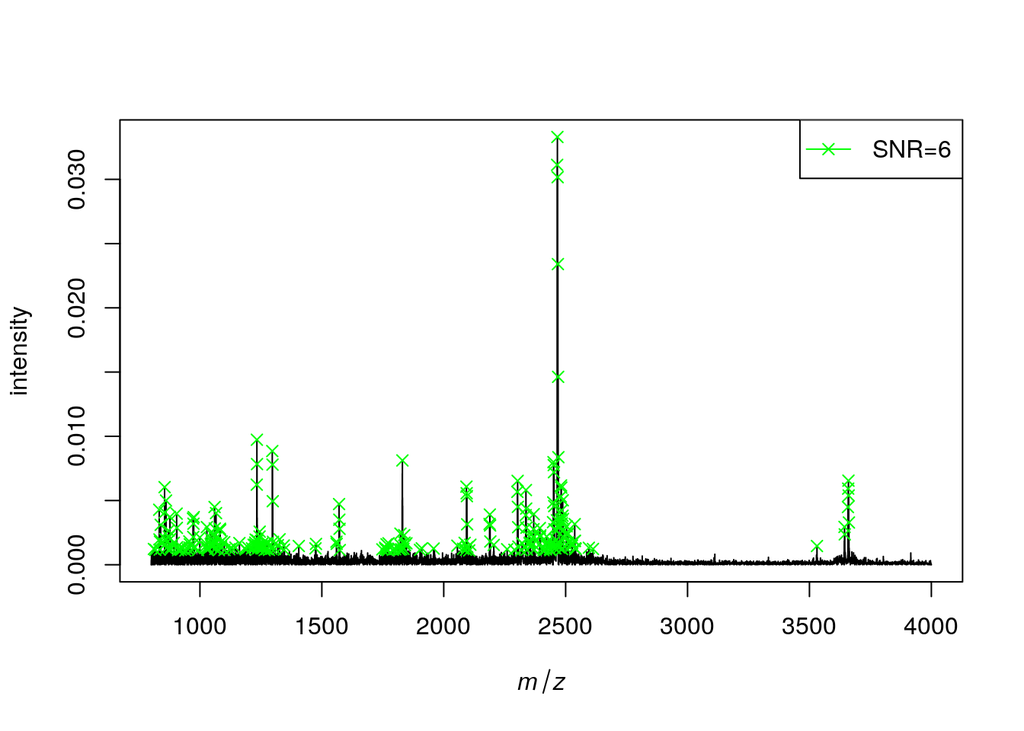

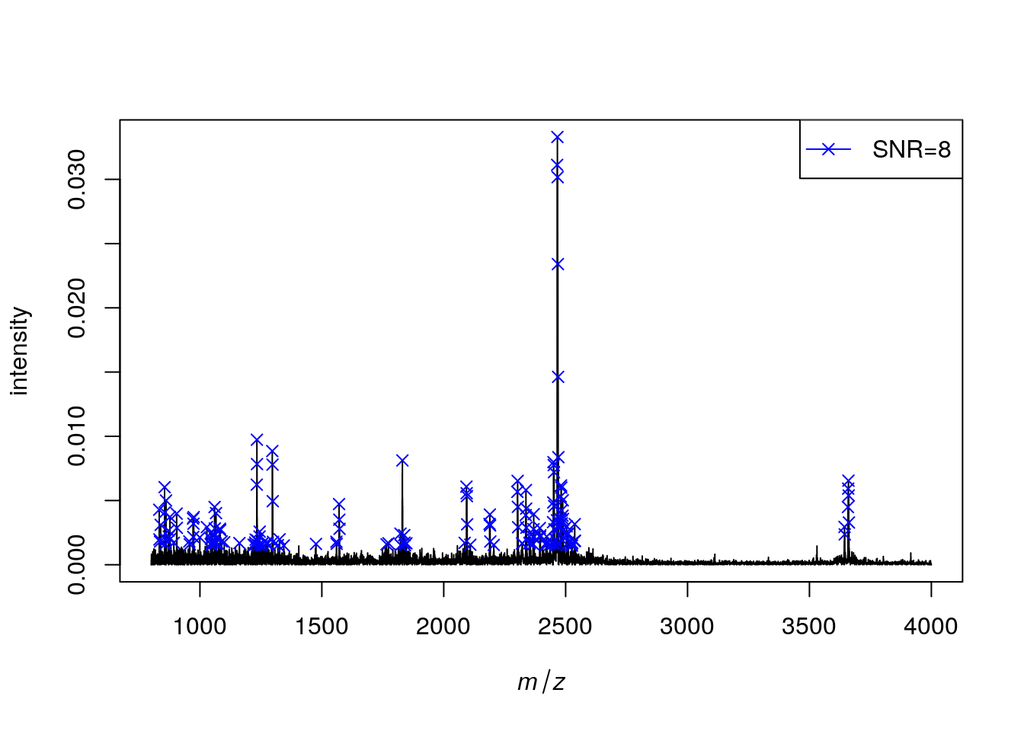

```r
for (i in 1:length(snr_values)){
  peaks = get_peaks(
    list(spectra_test), detectionMethod='MAD',
    SNR=snr_values[i], halfWindowSize=hws)[[1]]
  # peaks = detectPeaks(spectra_test, method='MAD',
  #                     SNR=snr_values[i], halfWindowSize=hws)
  plot_peaks(spectra_test, peaks, method='MAD',
             snr=snr_values[i], col=snr_colors[i])
}
```

### SuperSmoother noise estimator

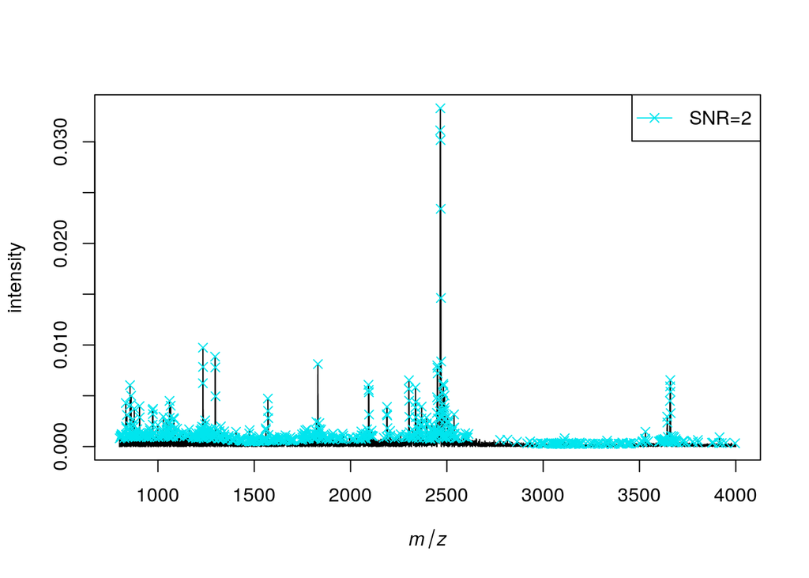

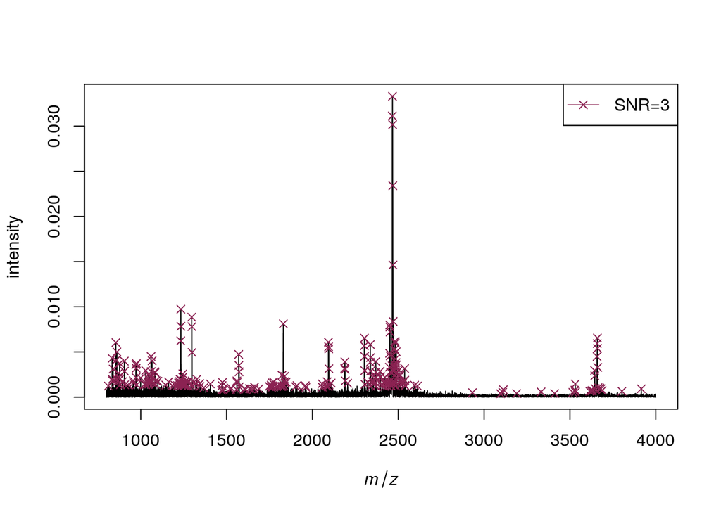

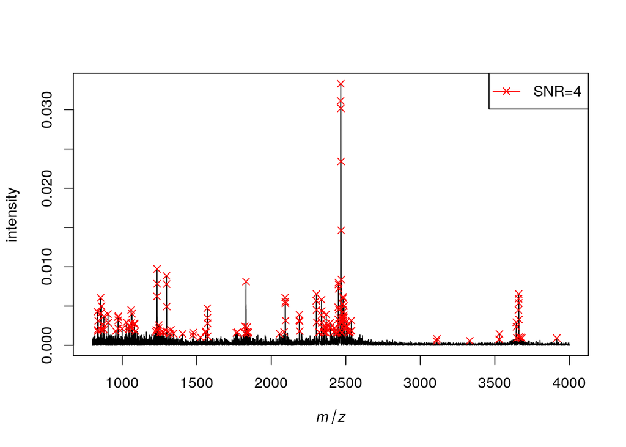

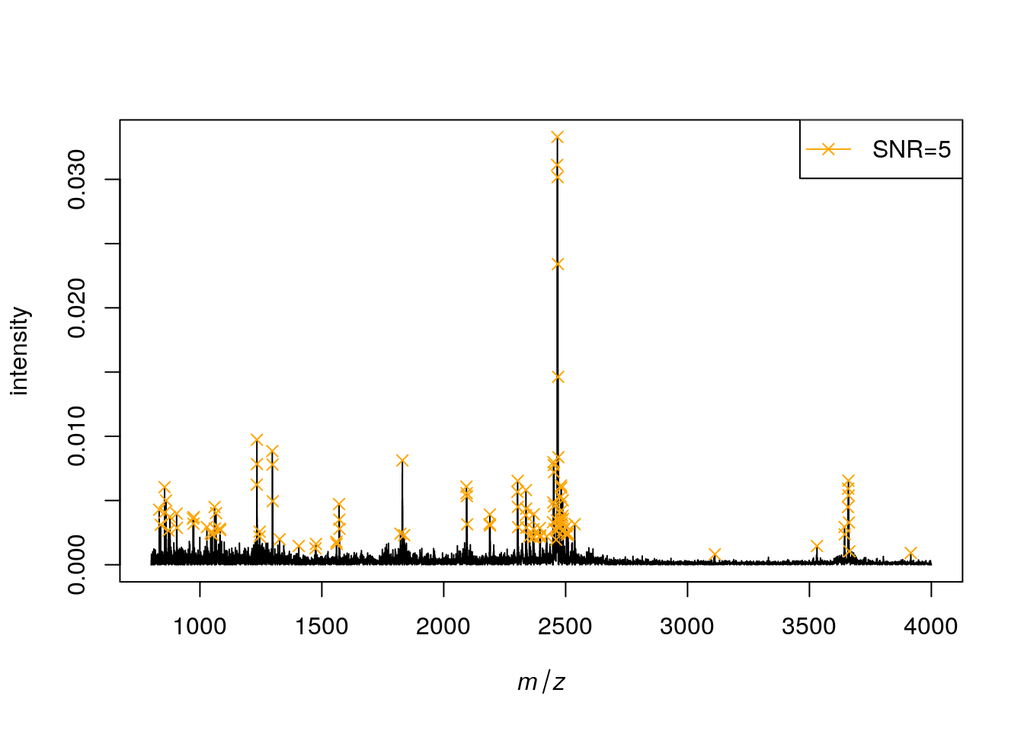

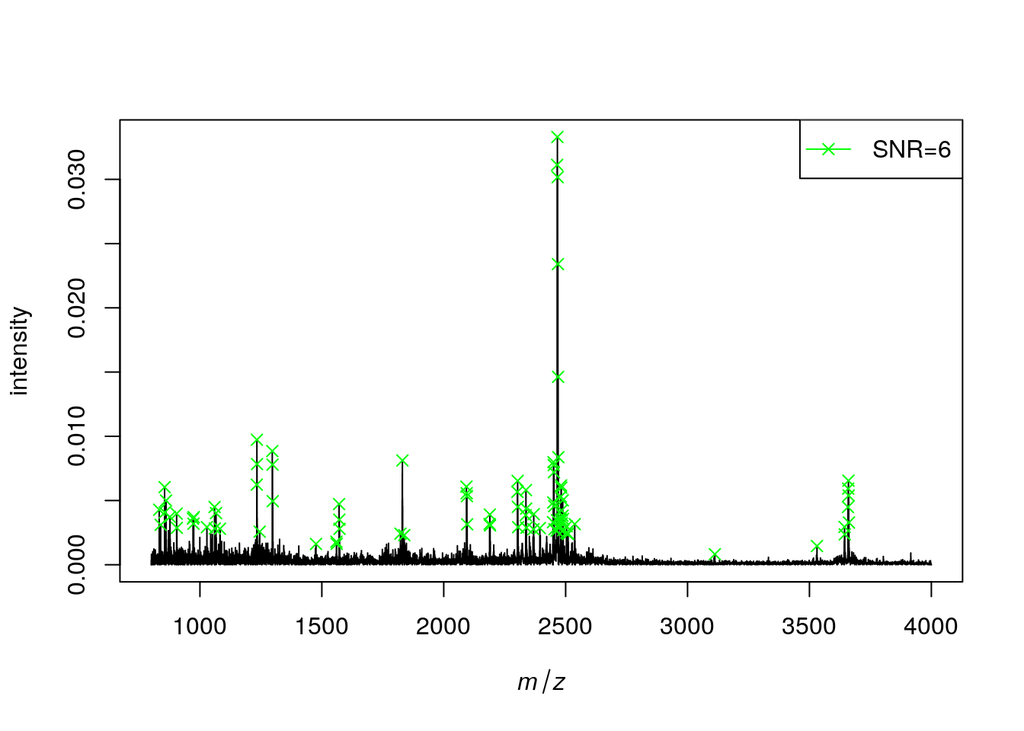

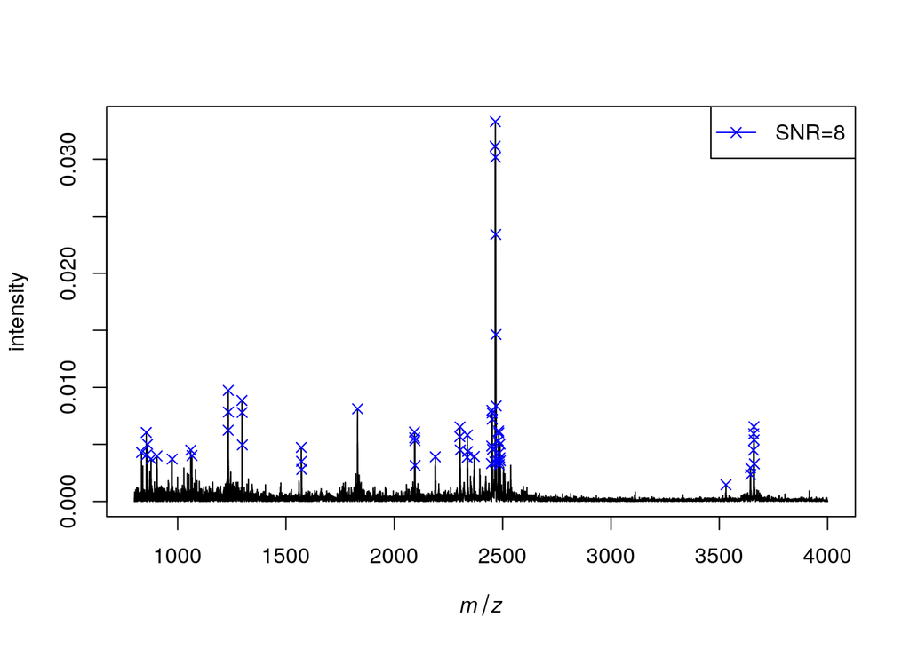

```r
for (i in 1:length(snr_values)){
  peaks = get_peaks(
    list(spectra_test), detectionMethod='SuperSmoother',
    SNR=snr_values[i], halfWindowSize=hws)[[1]]
  # peaks = detectPeaks(spectra_test, method='SuperSmoother',
  #                     SNR=snr_values[i], halfWindowSize=hws)
  plot_peaks(spectra_test, peaks,
             snr=snr_values[i], col=snr_colors[i])
}
```

### CWT noise estimator

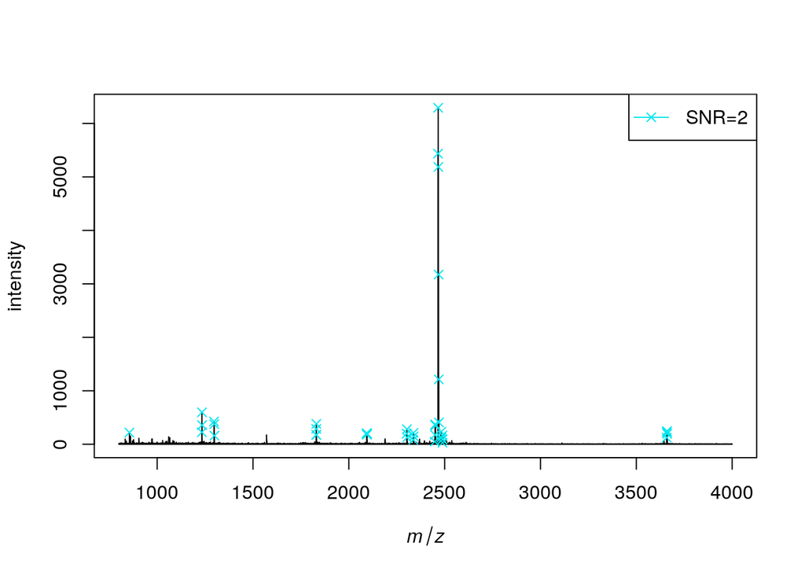

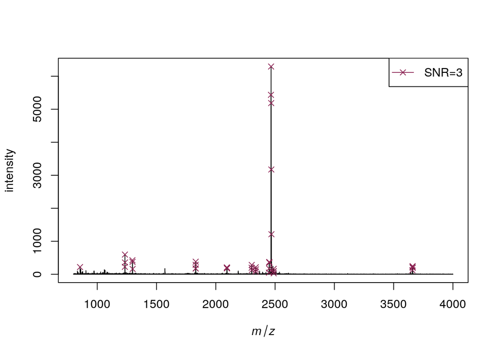

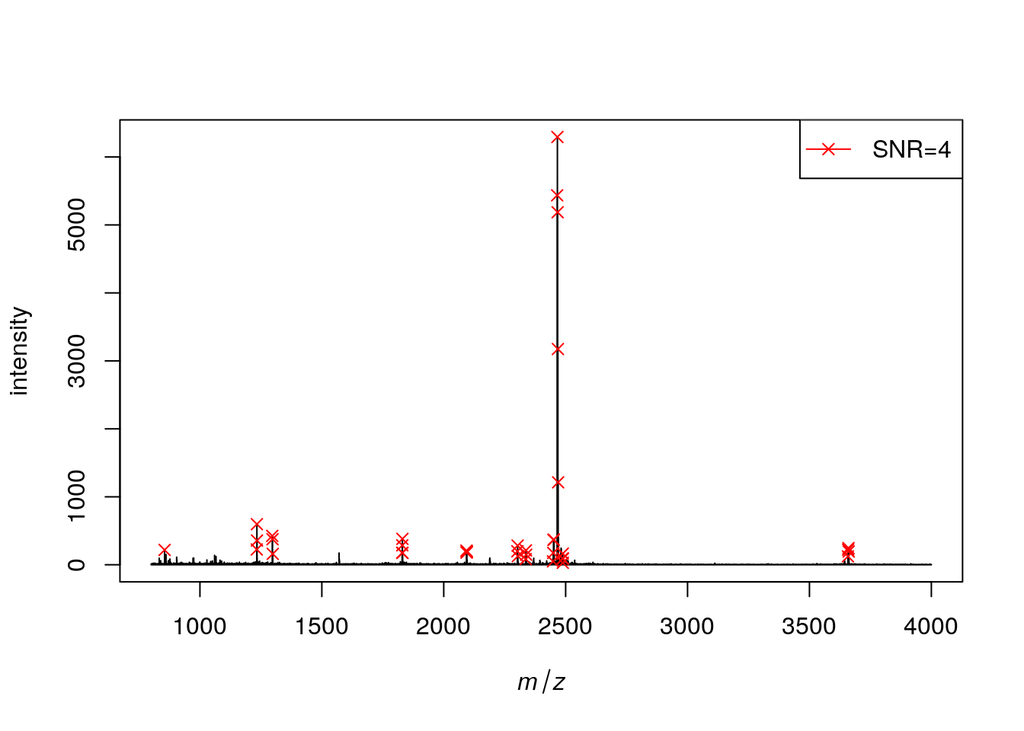

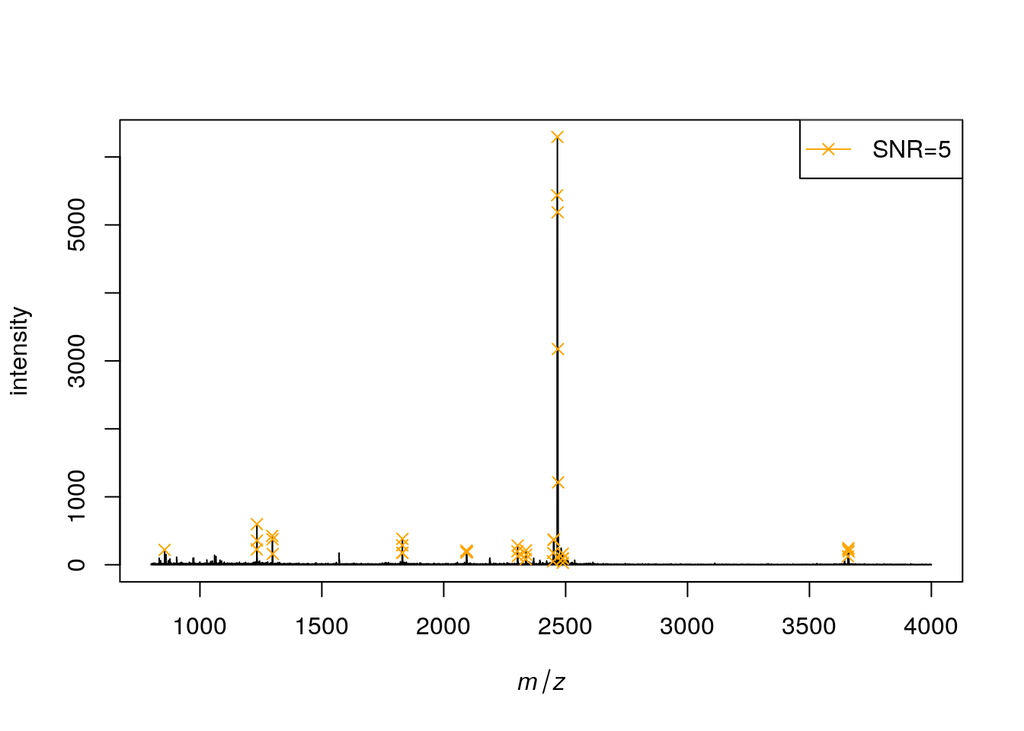

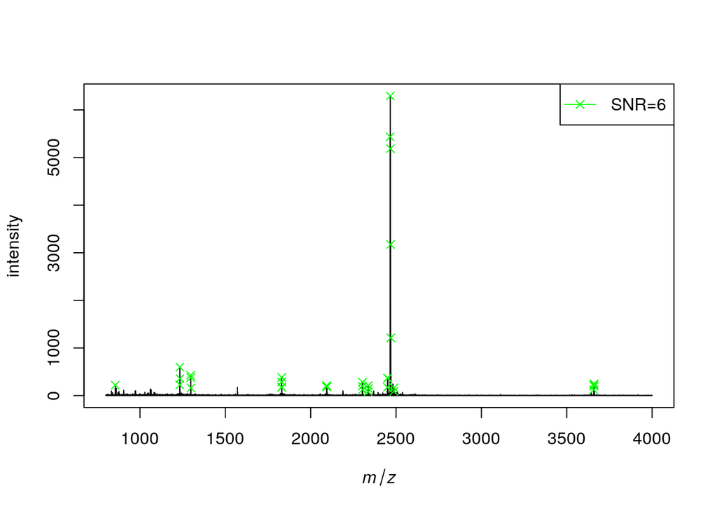

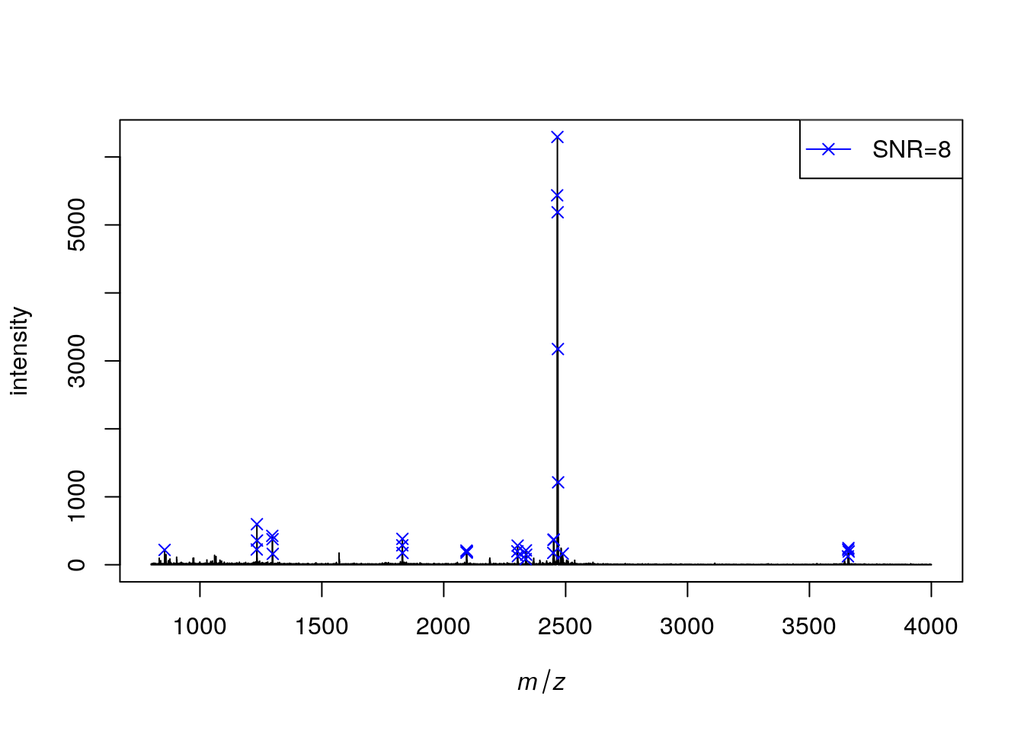

```r
for (i in 1:length(snr_values)){
  peaks = get_peaks(
    list(unproc_spectra_test), detectionMethod='CWT',
    SNR.Th = snr_values[i], nearbyPeak = T)[[1]]
  # peaks = custom_peakDetectionCWT(
  #   unproc_spectra_test,
  #   SNR.Th = snr_values[i], nearbyPeak = T
  # )
  plot_peaks(unproc_spectra_test, peaks,
             snr=snr_values[i], col=snr_colors[i])
}
```

The final preprocessing steps are: 1. Get peaks. We will use a SuperSmoother with SNR=5. 2. Align the peaks 3. Bin peaks 4. filterPeaks that only appeat in one of the 3 replicates 5. Merge peaks from different replicates from the same sample, using the average intensity 6. Get and write feature matrix and list of MassPeak

Define some functions for peak alignment based on MALDIquant and MALDIrppa. Basically, when creating the reference peaks, we allow the use of labels in the filtering step. This way we can account for peaks that are exclusive to one species and therefore have less total frequency.

```r
as.binary.matrix = function(m){
  stopifnot(is.matrix(m))
  isNA = which(is.na(m))
  m[] = 1L
  m[isNA] = 0L
  mode(m) = "integer"
  m
}

as.matrix.MassObjectList = function(l){
  mass = unlist(lapply(l, function(x)x@mass),
                recursive=FALSE, use.names=FALSE)
  intensity = unlist(lapply(l, function(x)x@intensity),
                     recursive=FALSE, use.names=FALSE)
  uniqueMass = sort.int(unique(mass))
  n = lengths(l)
  r = rep.int(seq_along(l), n)

  i = findInterval(mass, uniqueMass)

  m = matrix(NA_real_, nrow=length(l), ncol=length(uniqueMass),
             dimnames=list(NULL, uniqueMass))
  m[cbind(r, i)] = intensity
  attr(m, "mass") = uniqueMass
  m
}

custom_referencePeaks = function(l, minFreq, method, tolerance, labels){
  referencePeaks = filterPeaks(binPeaks(l, method=method,
                                        tolerance=tolerance),
                               minFrequency=minFreq,
                               labels=labels)

  m = as.binary.matrix(as.matrix.MassObjectList(referencePeaks))

  ## set peak intensity to number of occurrence
  intensity = unname(colMeans(m))

  createMassPeaks(mass=attr(m, "mass"), intensity=intensity)
}

custom_alignPeaks = function(l, minFreq, tolerance, labels, th_peaks=NULL){
  refPeaks = custom_referencePeaks(
    l,
    minFreq = minFreq,
    method = "strict",
    tolerance = tolerance,
    labels = labels
  )

  # if (!is.null(th_peaks)){
  #   refPeaks = binPeaks(list(refPeaks, th_peaks), method='relaxed')
  # }

  warpingFunctions = determineWarpingFunctions(
    l,
    reference = refPeaks,
    tolerance = tolerance,
    method='lowess'
  )
  l = warpMassPeaks(l, warpingFunctions)
  l = binPeaks(l, method = "strict", tolerance = tolerance)
  l = binPeaks(l, method = "relaxed", tolerance = tolerance)

  return(list(l, warpingFunctions))
}
```

```r
par(mfrow=c(1,1), mar=c(2,1,1,1))
snr=5
print(paste0('SNR = ',snr))
```

```
## [1] "SNR = 5"
```

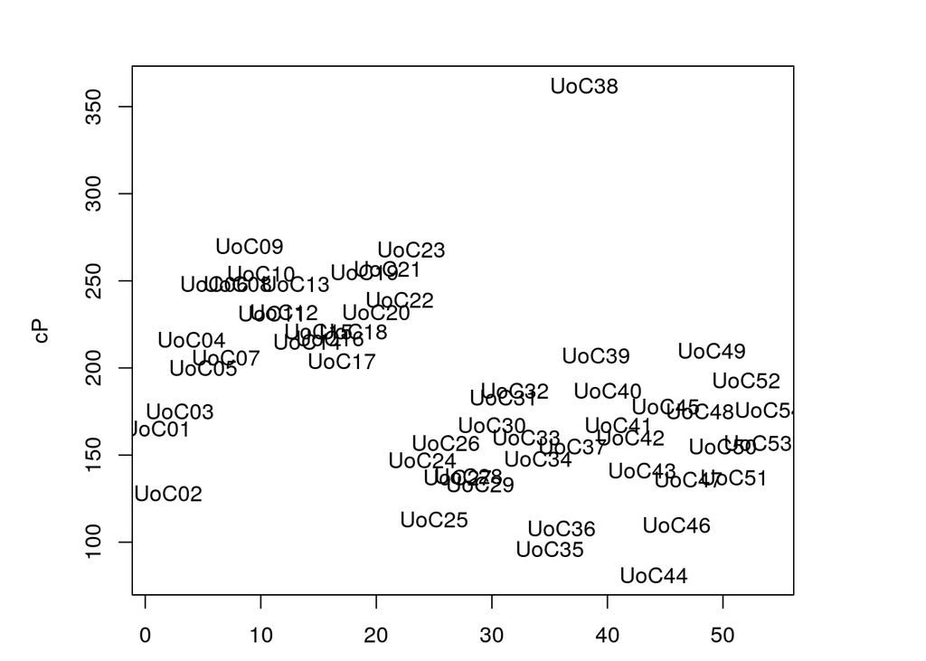

```r
# Detect peaks
pl = get_peaks(preprocessed_l, 'SuperSmoother', halfWindowSize=hws, SNR=snr, mc.cores=n_procs)

# Align peaks
a = custom_alignPeaks(pl, minFreq = minFreq,
                        labels=spectra_metadata$label,
                        tolerance = tolerance)
peaks = a[[1]]
warpingFunctions = a[[2]]

# Final bin peaks, relaxed
peaks = binPeaks(peaks, method='relaxed', tolerance=tolerance)

# Align spectra too using the warpingFunction calculated for the peaks
spectra = warpMassSpectra(preprocessed_l, w=warpingFunctions)

avgSpectra = averageMassSpectra(spectra, labels=spectra_metadata$sample,
                                method="mean")

peaks = filterPeaks(
    peaks, minFreq = 0.35,
    labels = spectra_metadata$sample,
    mergeWhitelists=TRUE
)


peaks_merged = mergeMassPeaks(peaks, labels = spectra_metadata$sample,
                              method = "mean")
options(repr.plot.width=6, repr.plot.height=5)
par(pin=c(5,4))
cP = countPeaks(peaks_merged)
plot(cP, type = "n")
text(cP, label = uoc_metadata$sample.name)
```

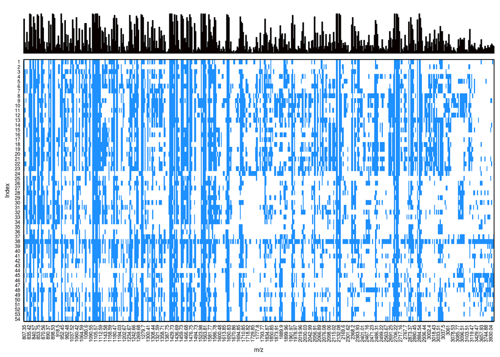

```r
# After filtering peak patterns
options(repr.plot.width=5, repr.plot.height=4)
par(mar=c(2,2,2,2), pin=c(5,4))
peakPatterns(peaks_merged)
```

```r
# Get the feature matrix from the peaks using the spectra to interpolate
featureMatrix = intensityMatrix(peaks_merged, avgSpectra)

# Export final spectra and final peaks
exportMzMl(mclapply(peaks_merged,
                    function(p){
                        createMassSpectrum(p@mass, p@intensity, p@metaData)
                    }
                    ),
            path=file.path(data_folder,paste0('final_mzml_peaks_', snr)),
            force=TRUE)
exportMzMl(avgSpectra, path=file.path(data_folder,paste0('final_mzml_spectra_', snr)),
           force=TRUE)

# Export feature matrix
write.csv(featureMatrix, row.names=F, col.names=T,
          file=file.path(data_folder, paste0('featureMatrix_', snr, '.csv')))
```